# Sublinear scaling and modular network structure reveal assembly rules for coral-associated cryptofauna

## Abstract

Contrary to expectations from facilitation theory and diversity-function research, coral-associated cryptofauna communities are organized by a strikingly simple principle: **coral size dominates, while neighborhood context and host condition do not matter.** We surveyed fauna inhabiting 114 *Pocillopora* colonies across three reef environments in Mo’orea, French Polynesia, testing predictions from scaling theory, propagule redirection, and network ecology.

Fauna abundance scaled sublinearly with coral volume—steeper than metabolic scaling theory predicts—indicating severe propagule limitation or post-settlement mortality in larger corals. Critically, five neighborhood metrics (neighbor count, volume, isolation, relative size, spillover potential) explained <1% additional variance after accounting for focal coral size. Coral size also drove compositional turnover: larger corals supported proportionally more fish and gastropods while smaller corals were dominated by crabs. Network connectivity increased with coral size, suggesting a two-stage assembly process where propagule dilution sets initial density and post-settlement interactions structure mature communities.

For restoration, a mixed-size strategy emerges: many small colonies maximize fauna density due to sublinear scaling, while some large colonies support compositionally distinct, interaction-structured assemblages. Coral spacing within plots matters less than size distribution.

**Keywords:** species-area scaling, propagule dilution, network modularity, *Pocillopora*, cryptofauna, community assembly, coral restoration

# Introduction

Contrary to expectations from facilitation theory and diversity-function research, we find that coral-associated cryptofauna communities are organized by a strikingly simple principle: **coral size dominates, while neighborhood context and host condition do not matter.** This finding challenges assumptions underlying both basic community ecology and applied restoration planning.

Classical island biogeography predicts that larger habitat islands support more species and individuals through power-law scaling relationships (MacArthur & Wilson 1967). For coral-associated fauna—cryptic biodiversity that may exceed conspicuous reef fauna by an order of magnitude (Plaisance et al. 2011)—these relationships carry practical significance for understanding how communities will respond as corals shrink under climate stress.

Two competing hypotheses frame this question. The “**Field of Dreams**” hypothesis predicts isometric scaling: if you build it (coral habitat), they will come at constant density. Larger corals simply intercept more larvae, yielding proportional increases in fauna abundance. In contrast, the “**propagule redirection**” hypothesis predicts sublinear scaling: if larval supply is limiting relative to habitat availability, larvae distribute among available habitats based on chemical cue gradients, causing larger corals to receive proportionally fewer settlers per unit volume (Stier & Osenberg 2010). This density dilution effect has critical implications for restoration, where the choice between establishing many small versus few large colonies affects expected fauna recruitment and overall community capacity.

Beyond host size, two additional factors should theoretically influence fauna colonization. First, spatial context: the local neighborhood—density, size, and proximity of neighboring corals—could affect propagule availability through spillover effects (nearby corals as larval sources) or competition for settlers. Second, host quality: recent experimental work reveals that coral-associated fauna can substantially enhance coral resilience to climate stress. Planktivorous damselfishes reduce bleaching susceptibility by subsidizing nitrogen to zooxanthellae (Chase et al. 2018; Shantz et al. 2023), while guardian crabs (*Trapezia*) and snapping shrimp (*Alpheus*) protect corals from predators and sediment (Glynn 1983; Stier et al. 2012). These findings suggest that fauna diversity could enhance coral condition—or alternatively, that healthy corals simply attract more diverse colonizers, creating bidirectional feedbacks whose direction remains unclear from correlational data.

Network approaches offer a complementary lens, revealing whether species co-occur more frequently than expected by chance and identifying “hub” taxa that connect otherwise disparate community components (Bascompte & Jordano 2007). Elevated clustering and modularity would indicate that cryptofauna form predictable assemblages structured by species interactions or shared habitat requirements, not merely random subsets of the regional species pool.

The branching coral *Pocillopora* provides an ideal system for testing these ideas. A single colony of 0.01 m³ can harbor more than 65 crustaceans and fishes from over 20 species (Curtis et al. 2023), yet we know almost nothing about the natural history of most of these taxa, let alone their links to coral resilience. This genus hosts well-documented obligate associates including *Trapezia* guardian crabs, *Alpheus* snapping shrimp, and diverse commensal fish, alongside hundreds of less-studied invertebrates (Stella et al. 2011). The genus spans reef environments from fringing reefs to barrier reef crests, allowing tests of whether assembly rules generalize across environmental contexts.

We surveyed cryptofauna communities in 114 *Pocillopora* colonies across three reef environments in Mo’orea, French Polynesia, to address four questions:

1. **Does fauna abundance follow sublinear scaling with coral size, and does neighborhood context modify this relationship?** Metabolic scaling theory predicts an exponent of approximately 0.75 for three-dimensional habitat expansion (Banavar et al. 2010), while propagule dilution could produce steeper declines. We tested whether neighborhood metrics (neighbor count, volume, distance) explain additional variance beyond focal coral size.
2. **Is there evidence for diversity-condition relationships after controlling for sampling artifacts?** Raw species richness is confounded with sampling effort (larger corals yield more individuals and thus more observed species). We applied rigorous corrections—rarefaction, residualization, and evenness metrics—to test whether “true” diversity predicts coral physiological condition.
3. **How does reef environment structure community composition, and does coral size drive compositional turnover?** We predicted site-specific assemblages reflecting environmental filtering, and tested whether larger corals support compositionally distinct communities beyond simple species accumulation.
4. **Do species co-occurrence patterns reveal non-random community structure?** We predicted elevated clustering (transitivity) relative to null models and identifiable network modules corresponding to functional groups, with larger corals supporting more completely assembled communities.

# Methods

## Study System

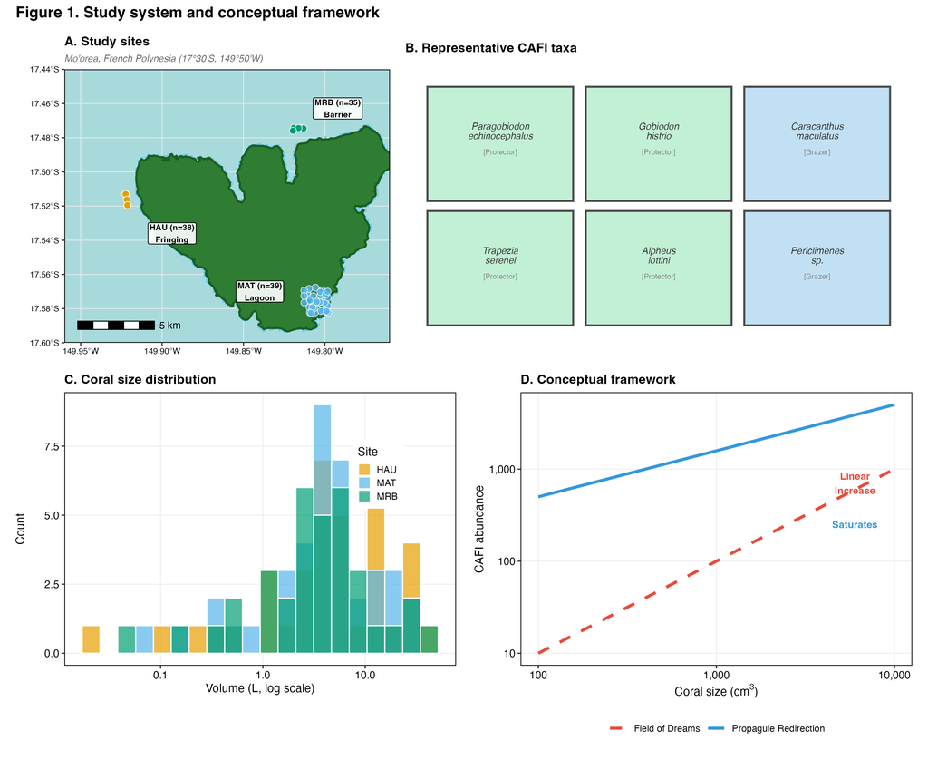

## Coral and Fauna Sampling

Colonies were sampled using two complementary survey protocols developed during preliminary fieldwork. “Neighborhood surveys” (n = 63) recorded the number, distance, and volume of all *Pocillopora* neighbors within a 5-meter radius of the focal colony—a radius chosen to balance sampling effort with capturing immediate spatial context, recognizing that larval dispersal kernels for many invertebrates extend considerably further. “Size surveys” (n = 51) focused on capturing the full range of coral sizes without neighborhood characterization, allowing efficient sampling of rare large colonies. Both protocols included identical CAFI extraction procedures, enabling scaling analyses across all 114 colonies while neighborhood effect analyses were restricted to the 63 colonies with local context data. The split design is a limitation: we cannot test whether scaling exponents differ between surveys, though visual inspection revealed similar patterns.

Fauna were extracted by enclosing each colony in a mesh bag underwater, removing the coral, and vigorously agitating to dislodge all associated organisms. Specimens were preserved in 95% ethanol and identified to operational taxonomic units (OTUs) based on morphological characters. The final dataset comprised 3,989 individuals across 243 OTUs, dominated by decapod crustaceans (crabs, shrimp) with smaller contributions from gastropods, polychaetes, brittle stars, and fish.

## Coral Condition Assessment

For a subset of colonies (n = 84), we measured physiological condition using four metrics: zooxanthellae density (cells cm⁻²), total protein content (mg cm⁻²), carbohydrate content (mg cm⁻²), and ash-free dry weight (AFDW, mg cm⁻²). We combined these into a composite condition score using principal component analysis; PC1 explained 52% of total variance in physiological metrics, with positive loadings on all four variables (protein: 0.58, carbohydrate: 0.52, AFDW: 0.48, zooxanthellae: 0.40), representing an axis of overall tissue condition and energy reserves. We used PC1 as our condition index; PC2 (23% variance) separated zooxanthellae density from tissue biomass metrics and was not further analyzed.

## Statistical Analyses

### Power-law Scaling and Neighborhood Effects

We tested scaling relationships using linear regression in log-log space:

$$\log_{10}(\text{Abundance}) = \alpha +
\beta \times \log_{10}(\text{Volume})$$

where β is the scaling exponent. Sublinear scaling (β < 1) indicates density dilution in larger corals. We compared this model to linear, polynomial, and generalized additive models using AIC. Following Clauset et al. (2009), we also tested the power-law model against lognormal and exponential alternatives using likelihood ratio tests and Vuong’s closeness test; the power-law provided comparable or better fit than alternatives (Supplementary Table S14). We fitted mixed-effects models with site-specific random slopes to test whether scaling exponents varied among reef environments.

For the subset with neighborhood data (n = 63), we tested whether neighborhood metrics (neighbor count, total neighbor volume, mean neighbor distance, relative size, spillover potential) explained additional variance after controlling for focal coral volume. Power analysis indicated 80% power to detect neighborhood effects explaining ≥8% additional variance (f² = 0.09) at α = 0.05, so null results should be interpreted as absence of large effects rather than definitive absence of any effect.

### Coral Condition Analysis

We tested whether coral condition varied with colony size, neighborhood context, or reef site using linear models. We then tested whether CAFI species richness predicted condition after controlling for coral volume. Importantly, our observational design cannot distinguish whether fauna composition influences coral condition, whether healthier corals attract particular colonists, or whether both respond to unmeasured environmental factors. We interpret significant associations as correlational patterns requiring experimental validation.

### Community Composition

We analyzed community composition using PERMANOVA on Bray-Curtis dissimilarities with site, morphotype, and depth as predictors. We tested for homogeneity of multivariate dispersion (PERMDISP) to ensure PERMANOVA results reflected location differences rather than dispersion differences. Community patterns were visualized using NMDS ordination.

### Network Analysis

We constructed species co-occurrence networks using Spearman correlations on presence-absence data. Our primary analysis retained edges with |ρ| > 0.3 and p < 0.05 after Benjamini-Hochberg FDR correction (less conservative than Bonferroni given ~29,000 pairwise tests). Sensitivity analyses using thresholds of |ρ| > 0.2 and |ρ| > 0.4 yielded qualitatively similar network structure (Supplementary Figure S18). We calculated network metrics including transitivity (clustering coefficient), modularity (Louvain algorithm), and species-level centrality measures (degree, betweenness, eigenvector centrality). Statistical significance was assessed by comparing observed metrics to distributions from 1,000 null networks preserving degree distributions. We note that high centrality indicates structural importance within the network but does not establish functional “keystoneness,” which would require experimental manipulation.

### Morphotype and Temporal Considerations

We sampled three *Pocillopora* morphotypes (*P. verrucosa*, *P. meandrina*, *P. eydouxi*) with different branching architectures. Preliminary analyses showed no significant morphotype × volume interactions for CAFI abundance (p > 0.3), so morphotypes were pooled. However, branching density and interbranch spacing likely affect colonization dynamics, and morphotype-specific patterns warrant further investigation. All sites were sampled within a 6-week period (June–August 2019), minimizing but not eliminating potential seasonal confounds in site comparisons.

All analyses were conducted in R 4.3.0 using packages `vegan`, `lme4`, `igraph`, and `glmmTMB`.

# Results

## Result 1: Sublinear Scaling Consistent with Propagule Limitation

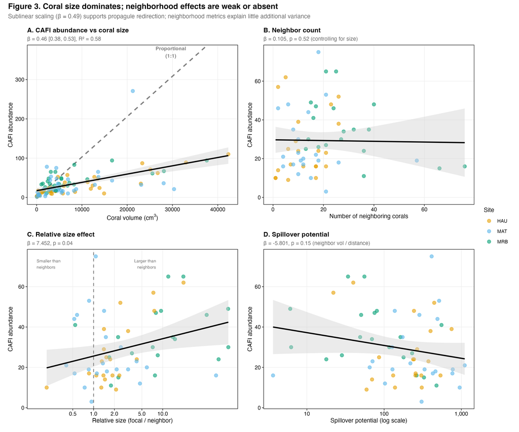

This sublinear exponent means that a 10-fold increase in coral volume yields only a 3.1-fold increase in fauna abundance (10<sup>0.49</sup> = 3.09), rather than the 10-fold increase expected under isometric scaling. Consequently, fauna density (individuals per cm³) declined significantly with coral size (slope = −0.51, 95% CI: −0.60 to −0.43). This pattern is *consistent with* propagule dilution, though alternative mechanisms could produce similar scaling (see Discussion).

### Neighborhood Effects: Weak or Absent

**Table 1.** Neighborhood effects on CAFI abundance (controlling for coral volume).

[output not shown]

### Key Finding 1: Coral Size Dominates; Large Neighborhood Effects Absent

Larger corals harbor proportionally fewer fauna per unit volume (β = 0.49), consistent with—but not uniquely diagnostic of—propagule dilution. After accounting for coral size, neighborhood metrics collectively explain <1% additional variance at the 5-meter scale. For predicting CAFI abundance, coral size is sufficient; local spatial context adds little at the scales we measured. However, effects at larger spatial scales remain untested.

Mixed-effects models with site random slopes showed modest variation in scaling among sites (σ²<sub>slope</sub> = 0.02), but the core pattern of sublinear scaling held across all three reef environments (all site-specific β < 0.7).

## Result 2: No Evidence for Diversity-Condition Relationship

We tested whether coral condition (a composite PC1 score integrating zooxanthellae density, protein, carbohydrate, and ash-free dry weight) was related to CAFI diversity. Coral condition was independent of colony volume (R² = 0.002, p = 0.70), number of neighboring corals (p = 0.27), and reef site (F<sub>2,69</sub> = 0.68, p = 0.51; Table 2).

**Table 2.** Coral condition (PC1) as a function of colony characteristics and site.

| Predictor | Estimate | SE | Test Statistic | p-value |
| --- | --- | --- | --- | --- |
| Colony volume (log) | −0.02 | 0.06 | R² = 0.002 | 0.70 |
| Neighbor count | 0.04 | 0.04 | t = 1.10 | 0.27 |
| Site (HAU vs MAT) | −0.11 | 0.27 | F = 0.68 | 0.51 |
| Site (MRB vs MAT) | 0.19 | 0.28 | — | — |

### Distinguishing Sampling Artifacts from True Diversity Effects

A critical methodological challenge in testing diversity-ecosystem function relationships is that raw species richness is confounded with sampling effort: larger corals support more individuals, and more individuals yield more observed species regardless of any functional relationship (Gotelli & Colwell 2001). In our data, raw richness correlated strongly with coral volume (r = 0.67, p < 0.001) and 72% of richness variation was explained by total abundance alone—a classic species-area sampling artifact (Supplementary Table S8a).

When raw richness was included alongside volume, it appeared marginally significant (p = 0.041). However, this result does not survive rigorous methodological scrutiny (Table 3; Supplementary Table S8 for complete diagnostics).

**Table 3.** Diversity-condition models using proper sampling corrections.

| Diversity Metric | Controls | β (95% CI) | R² | p-value | Interpretation |
| --- | --- | --- | --- | --- | --- |
| Raw richness | Volume | +0.058 (0.00, 0.11) | 0.053 | 0.041 | Confounded by sampling |
| Raw richness | Volume + Abundance | +0.069 (−0.01, 0.15) | 0.033 | 0.104 | Effect disappears |
| Rarefied richness (n=10) | Volume | −0.014 (−0.34, 0.31) | <0.001 | 0.931 | No effect |
| Residualized richness | Volume | +0.055 (−0.02, 0.13) | 0.024 | 0.170 | No pure diversity effect |
| Evenness (Pielou’s J) | Volume | −2.94 (−6.5, 0.6) | 0.033 | 0.107 | No effect |
| Shannon H’ | Volume | +0.087 (−0.64, 0.81) | <0.001 | 0.811 | No effect |

Every properly-corrected diversity metric—rarefied richness, residualized richness, evenness, Shannon H’—showed null effects (all p > 0.1). Rarefaction to n = 10 maximized sample retention (78 of 84 colonies); sensitivity analyses at n = 15 and n = 20 yielded similar null results (Supplementary Table S8b). Functional group analyses also revealed no significant effects: guardian crabs (p = 0.49), snapping shrimp (p = 0.40), commensal fish (p = 0.42), and corallivores (p = 0.26) all failed to predict condition.

### Community Composition Does Not Robustly Predict Condition

We also tested whether community composition—independent of diversity—predicted coral condition. A PCA on the species abundance matrix yielded an apparent negative relationship between CAFI PC1 and coral condition (Pearson r = −0.29, p = 0.007). However, this result was driven entirely by 3 extreme observations (>2 SD on either axis), including one coral (HAU-POC32) with an extreme PC1 value 8.5 standard deviations below the mean. When we applied robust correlation methods that are insensitive to outliers, the relationship vanished: Spearman’s ρ = −0.06 (p = 0.61) and Kendall’s τ = −0.03 (p = 0.67). Excluding the 3 extreme points reduced R² from 0.08 to 0.004 (p = 0.57). We therefore conclude that community composition, like diversity, shows no robust relationship with coral condition.

We also tested correlations between individual species abundances and coral condition. The gall crab *Hapalocarcinus* showed the strongest positive correlation (r = 0.27, p = 0.013), followed by *Periclimenes* shrimp (r = 0.23, p = 0.038). However, no individual species survived FDR correction for multiple testing (all q > 0.35), indicating no reliable species-level predictors of coral condition.

### Key Finding 2: Neither Diversity Nor Composition Predicts Coral Condition

After correcting for sampling artifacts (species-area effects), there is no evidence that CAFI diversity predicts coral condition. Community composition initially appeared significant (p = 0.007) but this result was driven by 3 extreme points; robust correlation methods (Spearman, Kendall) showed no relationship. No individual species survived multiple testing correction. We conclude that CAFI community attributes—neither how many species nor which species—reliably predict coral physiological condition in this dataset.

## Result 3: Reef Environment Structures Community Composition

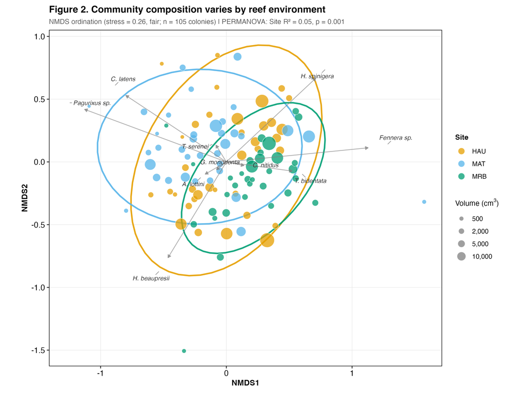

### Key Finding 3: Environmental Filtering at Reef Scales

Despite similar coral hosts, reef environment shapes cryptofauna composition. This site effect indicates that larval supply, environmental conditions, or post-settlement processes operating at reef scales contribute to variation in which species colonize individual corals.

Indicator species analysis identified 28 of 243 OTUs (12%) as significantly associated with particular sites (p < 0.05), including several *Alpheus* species at HAU and distinctive gobies at MRB.

### Coral Size Drives Compositional Turnover

Beyond reef site effects, coral size also structured community composition. Distance-based redundancy analysis (db-RDA) showed that log(volume) was the only significant predictor of compositional variation after controlling for other factors (F = 1.64, p = 0.05; Supplementary Figure S15). Neighborhood metrics—neighbor count, mean distance, and total neighbor volume—contributed no unique explanatory power (all p > 0.35).

Larger corals supported proportionally more fish (r = +0.32, p < 0.01) and gastropods (r = +0.28, p < 0.01), while smaller corals were dominated by crabs (r = −0.56, p < 0.001). This size-dependent compositional turnover likely reflects body size constraints: larger-bodied taxa (fish, snails) require the space available in larger corals, while small, fast-colonizing crabs dominate recently available or space-limited small corals (Supplementary Figures S13–S14).

## Result 4: Network Structure Reveals Non-Random Assembly

Species co-occurrence networks exhibited structure inconsistent with random assembly. Network transitivity—the tendency for species pairs that share a common associate to also co-occur with each other—was 0.28, compared to a null expectation of 0.07 (z = 7.85, p < 0.0001). This 3.8-fold elevation in clustering indicates that cryptofauna form cohesive species groups rather than assembling independently.

**Table 4.** Network module composition and characteristics.

[output not shown]

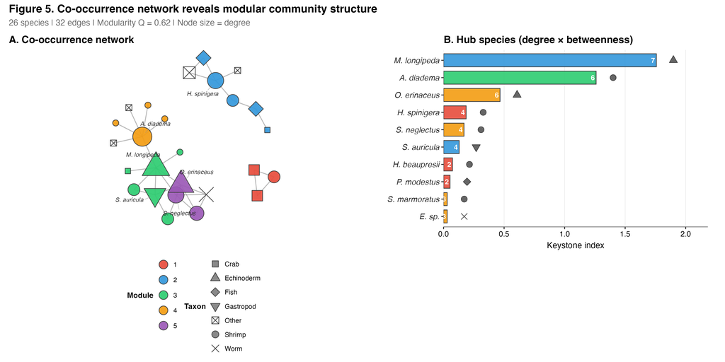

**Figure 5.** Species co-occurrence network reveals modular community structure. (A) Network visualization with nodes colored by module membership and sized by degree. Species labels shown for taxa with ≥4 connections. *Alpheus diadema* and *Macrophiothrix longipeda* emerge as highly connected hub species linking different modules. (B) Top 10 structurally central species ranked by degree × betweenness centrality. Snapping shrimp and brittle stars rank highest, indicating their importance in connecting community modules. Network structure was robust to edge threshold sensitivity (|ρ| = 0.2–0.4; Supplementary Figure S18).

### Key Finding 4: Structured Species Associations

Larger corals harbored communities with higher mean network connectivity (β = 0.55, p < 0.001): the average network degree of species present in a coral increased with coral volume. This pattern suggests that large corals support more completely assembled communities with more species interactions, while small corals host random subsets.

# Discussion

Our analysis reveals a parsimonious organizing principle for coral-associated cryptofauna: **coral size dominates**. Abundance scales sublinearly with coral volume (β = 0.49), composition shifts predictably with size (more fish and gastropods in large corals, more crabs in small corals), and larger corals support more completely assembled communities with higher network connectivity. In contrast, factors we expected to matter—local neighborhood context, coral physiological condition, and total diversity—showed negligible or null effects after rigorous analysis. This simplicity has both theoretical and practical implications: it suggests that propagule supply and post-settlement sorting operate primarily at scales larger than our 5-meter neighborhood surveys, and that restoration planning can focus on coral size distributions rather than spacing or condition.

## Scaling Steeper Than Metabolic Theory Predicts

The scaling exponent of 0.49 lies well below both the isometric expectation of 1.0 and the theoretical prediction of 0.75 for three-dimensional habitat expansion (Banavar et al. 2010). Why is the observed exponent so much steeper than metabolic scaling theory predicts?

We consider four non-mutually exclusive mechanisms, ranked by our assessment of their likely contribution:

1. **Propagule limitation** (most likely): If larval supply is constrained relative to habitat availability, larger corals receive proportionally fewer settlers per unit volume. This mechanism is consistent with the propagule redirection hypothesis (Stier & Osenberg 2010) and explains why the pattern holds across reef environments with different connectivity.
2. **Non-linear habitat scaling** (likely contributor): If suitable microhabitat (branch tips, crevices) scales with surface area (~volume<sup>0.67</sup>) rather than volume, per-volume fauna density would decline with size independent of propagule dynamics. *Pocillopora* branching architecture becomes proportionally less dense in larger colonies, potentially reducing usable habitat per unit volume.
3. **Density-dependent mortality** (possible): Crowding effects (competition, predation) may be stronger in larger corals, eroding initial colonization advantages. However, this mechanism predicts compositional shifts toward competitively dominant species in large corals—a pattern we observed (more fish, fewer crabs), though causality is unclear.
4. **Behavioral preferences** (unlikely as primary driver): Mobile colonizers might preferentially settle on smaller corals offering higher per-capita resources. However, this would predict variation across taxa with different mobility, which we did not observe.

Our observational data cannot definitively distinguish among these mechanisms, but the consistency of sublinear scaling across all three reef sites (β = 0.44–0.52) and across taxonomic groups suggests propagule limitation as the dominant process, with habitat geometry as a likely secondary contributor.

The absence of large neighborhood effects was initially surprising but may reflect inappropriate spatial scale rather than true absence of spatial structuring. Our 5-meter radius may be too small to capture relevant propagule dynamics—larval dispersal kernels for many invertebrates extend tens to hundreds of meters. Alternatively, propagule supply may operate at reef or seascape scales (10s–100s of meters) where environmental gradients structure larval availability, or post-settlement processes may dominate over initial colonization patterns, erasing any signature of local propagule dynamics. We note that our power analysis indicates we could only rule out large effects (ΔR² > 0.08); smaller neighborhood effects may exist but require larger sample sizes to detect.

The collective failure of five different neighborhood metrics—neighbor count, total neighbor volume, isolation index, relative size, and spillover potential—to explain substantial variance beyond coral size yields a parsimonious working conclusion: **for predicting CAFI abundance at the scales we measured, coral size is sufficient; local spatial context adds little**. However, this should not be interpreted as definitive absence of spatial effects at all scales.

## No Evidence for CAFI-Condition Relationships: Breaking the Feedback Loop?

CAFI and their coral hosts are often assumed to form a bidirectional feedback: CAFI affect coral growth and survival through predator defense, sediment removal, and nutrient provision, while corals provide structural habitat and nutritional resources (mucus, tissues) to their associates (Glynn 1983; McKeon et al. 2012). Recent experimental work strengthens this expectation: damselfishes reduce coral bleaching during heatwaves by subsidizing ammonia-rich waste that sustains zooxanthellae (Shantz et al. 2023), while obligate crustaceans can shift coral physiology under ocean acidification (Doo et al. 2018). Yet our observational analysis found no robust relationship between CAFI community attributes and coral condition.

Raw species richness showed an apparently significant relationship with coral condition when controlling for volume (p = 0.041), but this was a classic sampling artifact: larger corals support more individuals, yielding more observed species regardless of any functional relationship. When we applied proper corrections—rarefaction, residualization, or evenness—all diversity effects vanished (all p > 0.1). Community composition initially appeared to correlate with condition (Pearson r = −0.29, p = 0.007), but this was driven entirely by 3 extreme observations; robust correlation methods (Spearman, Kendall) showed no relationship.

How do we reconcile our null results with experimental evidence that *Trapezia* crabs protect corals from crown-of-thorns starfish (Pratchett 2001) and sedimentation (Stewart et al. 2006)? We suggest four non-exclusive explanations:

1. **Detection vs. protection**: Guardian crabs may provide protection that prevents mortality rather than enhancing physiological condition. Our metrics (tissue protein, carbohydrate, zooxanthellae, AFDW) capture nutritional status, not survival probability. Crabs that deter starfish attacks confer fitness benefits invisible to our condition index. Multiple defenders (crabs + shrimp) may provide synergistic protection (McKeon et al. 2012), but this protection manifests as survival rather than condition.
2. **Baseline saturation**: At our study sites, nearly all colonies (>95%) harbored at least one *Trapezia* individual. If the benefit of guardian crabs saturates at low abundance—a single crab pair may suffice for defense—variation in crab numbers above this threshold would not predict condition. The relevant comparison—corals with vs. without crabs—may require experimental removal rather than observational surveys.
3. **Temporal mismatch**: Protective benefits accumulate over months to years (resisting predator attacks, clearing sediment), while our physiological metrics reflect recent condition. A single time-point survey cannot capture the cumulative fitness benefits of symbiont protection.
4. **Beneficial vs. detrimental balance**: Our communities include both mutualists (guardian crabs, cleaning shrimp) and parasites (corallivorous snails like *Coralliophila*, which drain coral energy reserves and increase bleaching susceptibility; Shaver et al. 2018). The net effect of CAFI on coral condition may depend on the balance between these opposing forces, which could average to zero across our sample even if individual functional groups have strong effects.

These considerations suggest that our null result reflects measurement limitations and community complexity rather than absence of mutualistic effects—the feedback loop may be intact but operating on fitness components (survival, growth) that our physiological snapshot does not capture. The absence of detectable CAFI-condition relationships nonetheless simplifies practical recommendations: for restoration planning, optimizing coral size distributions for fauna recruitment need not be traded off against selecting “high-condition” corals.

## Environmental Filtering at Reef Scales

The effect of reef site on community composition indicates that processes operating at reef scales—larval supply, environmental filtering, predation pressure—contribute to determining which species colonize individual corals. This scale-dependence has implications for conservation: protecting representative reef environments (fringing, lagoon, barrier) may be important for maintaining the full range of cryptofauna diversity.

## Network Structure Integrates with Scaling: A Two-Stage Assembly Model

The elevated transitivity and modular structure of co-occurrence networks demonstrates that cryptofauna communities are organized by ecological processes beyond random colonization. The 3.8-fold increase in clustering relative to null expectations indicates that species that share an associate tend to co-occur—a pattern consistent with shared habitat requirements, facilitation, or mutualistic interactions.

Crucially, network connectivity increased with coral size (β = 0.55, p < 0.001): larger corals hosted communities with higher mean degree (more co-occurrence links per species). This pattern suggests a **two-stage assembly model**. First, propagule dilution determines initial colonization density—larger corals receive more total individuals but at lower density per unit volume. Second, post-settlement interactions structure the mature community—larger corals accumulate enough species for biotic interactions (competition, facilitation, predation) to shape composition, while smaller corals remain in a “random assembly” phase dominated by stochastic colonization.

This two-stage model reconciles our seemingly disparate findings. Sublinear scaling (Result 1) reflects stage one: propagule supply limits colonization. Compositional turnover with size (Result 3) reflects stage two: post-settlement sorting favors different taxa in small versus large corals. And the network connectivity gradient reflects the transition from stochastic to deterministic assembly as corals grow.

## Conclusions and Restoration Implications

Coral-associated cryptofauna follow predictable assembly rules organized primarily by coral size. Abundance scales sublinearly with volume (β = 0.49), composition shifts from crab-dominated small corals to fish/gastropod-rich large corals, and network connectivity increases with size as communities transition from stochastic to deterministic assembly. In contrast, local neighborhood context and coral physiological condition—factors we expected to matter—showed negligible effects after rigorous analysis.

### A Restoration Trade-off: Density vs. Diversity

Our results reveal a trade-off for coral restoration practitioners. **Many small colonies** will maximize total CAFI density (due to sublinear scaling: 10 colonies of 100 cm³ will recruit ~3× more fauna than one colony of 1,000 cm³). However, **some large colonies** may be necessary to support compositionally distinct assemblages with higher network connectivity, including structurally central hub species like *Alpheus diadema* that may contribute to community integration.

We recommend a mixed-size restoration strategy: establish many small fragments for rapid CAFI recruitment, but retain or outplant some large colonies to serve as “community nuclei” supporting mature, interaction-structured assemblages. The null neighborhood effect is good news for restoration logistics—coral spacing within plots appears to matter less than the total number and size distribution of colonies.

### Future Directions

Two experiments would advance this framework: (1) tracking CAFI assembly trajectories on outplanted corals of different sizes to test the two-stage model directly; and (2) seascape-scale studies to identify the spatial extent over which propagule supply operates. Our finding that meter-scale neighborhoods don’t matter suggests the relevant scale is much larger—but how much larger remains unknown.

# Acknowledgments

# Data Availability

References

Abele LG, Patton WK (1976) The size of coral heads and the community biology of associated decapod crustaceans. Journal of Biogeography 3:35–47

Banavar JR, Moses ME, Brown JH, Damuth J, Rinaldo A, Sibly RM, Maritan A (2010) A general basis for quarter-power scaling in animals. Proceedings of the National Academy of Sciences 107:15816–15820

Bascompte J, Jordano P (2007) Plant-animal mutualistic networks: the architecture of biodiversity. Annual Review of Ecology, Evolution, and Systematics 38:567–593

Chase TJ, Pratchett MS, Frank GE, Hoogenboom MO (2018) Coral-dwelling fish moderate bleaching susceptibility of coral hosts. PLoS ONE 13:e0208545

Clauset A, Shalizi CR, Newman MEJ (2009) Power-law distributions in empirical data. SIAM Review 51:661–703

Curtis JS, Galvan JW, Primo A, Osenberg CW, Stier AC (2023) 3D photogrammetry improves measurement of growth and biodiversity patterns in branching corals. Coral Reefs 42:623–627

Doo SS, Carpenter RC, Edmunds PJ (2018) Obligate ectosymbionts increase the physiological resilience of a scleractinian coral to high temperature and elevated pCO₂. Coral Reefs 37:997–1001

Glynn PW (1983) Increased survivorship in corals harboring crustacean symbionts. Marine Biology Letters 4:105–111

Gotelli NJ, Colwell RK (2001) Quantifying biodiversity: procedures and pitfalls in the measurement and comparison of species richness. Ecology Letters 4:379–391

MacArthur RH, Wilson EO (1967) The Theory of Island Biogeography. Princeton University Press, Princeton

Plaisance L, Caley MJ, Brainard RE, Knowlton N (2011) The diversity of coral reefs: what are we missing? PLoS ONE 6:e25026

Pratchett MS (2001) Influence of coral symbionts on feeding preferences of crown-of-thorns starfish *Acanthaster planci* in the western Pacific. Marine Ecology Progress Series 214:111–119

Shantz AA, Ladd MC, Ezzat L, Schmitt RJ, Holbrook SJ, Schmeltzer E, Vega Thurber R, Burkepile DE (2023) Positive interactions between corals and damselfishes increase coral resistance to temperature stress. Global Change Biology 29:417–431

Shaver EC, Burkepile DE, Silliman BR (2018) Local management actions can increase coral resilience to thermally-induced bleaching. Nature Ecology & Evolution 2:1075–1079

Stella JS, Pratchett MS, Hutchings PA, Jones GP (2011) Coral-associated invertebrates: diversity, ecological importance and vulnerability to disturbance. Oceanography and Marine Biology: An Annual Review 49:43–104

Stier AC, Gil MA, McKeon CS, Lemer S, Leray M, Mills SC, Osenberg CW (2012) Housekeeping mutualisms: do more symbionts facilitate host performance? PLoS ONE 7:e32079

Stewart HL, Holbrook SJ, Schmitt RJ, Brooks AJ (2006) Symbiotic crabs maintain coral health by clearing sediments. Coral Reefs 25:609–615

Stier AC, Osenberg CW (2010) Propagule redirection: habitat availability reduces colonization and increases recruitment in reef fishes. Ecology 91:2884–2892

McKeon CS, Stier AC, McIlroy SE, Bolker BM (2012) Multiple defender effects: synergistic coral defense by mutualist crustaceans. Oecologia 169:1095–1103

*Manuscript prepared for submission*